# Conversion_EDA

Regan Yee

February 28, 2017

## Data Summaries

```r
## Examine the first row of the data
head(data,1)
```

```
##   country age new_user source total_pages_visited converted
## 1      UK  25        1    Ads                   1         0
```

```r
## Gets the summary of the data
summary(data)
```

```
##     country            age            new_user         source
##  China  : 76602   Min.   : 17.00   Min.   :0.0000   Ads   : 88740
##  Germany: 13056   1st Qu.: 24.00   1st Qu.:0.0000   Direct: 72420
##  UK     : 48450   Median : 30.00   Median :1.0000   Seo   :155040
##  US     :178092   Mean   : 30.57   Mean   :0.6855
##                   3rd Qu.: 36.00   3rd Qu.:1.0000
##                   Max.   :123.00   Max.   :1.0000
##  total_pages_visited   converted
##  Min.   : 1.000      Min.   :0.00000
##  1st Qu.: 2.000      1st Qu.:0.00000
##  Median : 4.000      Median :0.00000
##  Mean   : 4.873      Mean   :0.03226
##  3rd Qu.: 7.000      3rd Qu.:0.00000
##  Max.   :29.000      Max.   :1.00000
```

```r
## Let's factorize and re-level some boolean variables
data$new_user = as.factor(data$new_user)
levels(data$new_user) = c("No", "Yes")

data$converted = as.factor(data$converted)
levels(data$converted) = c("No", "Yes")
```

Let’s examine how many new users there were:

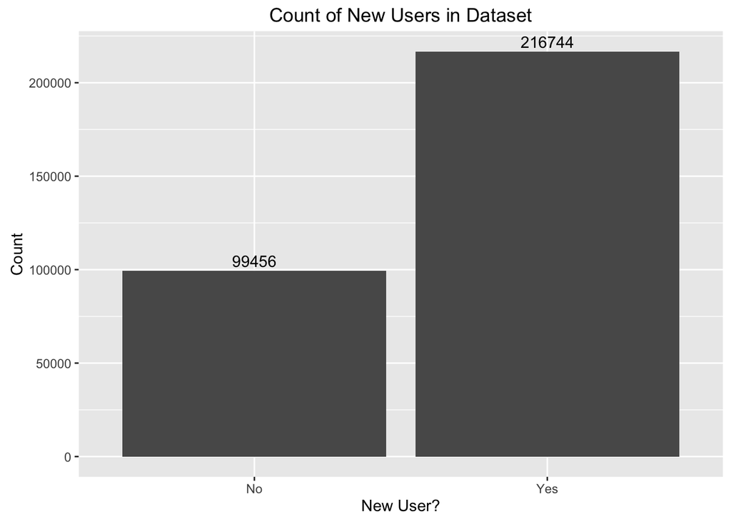

And how many people actually converted in this dataset?

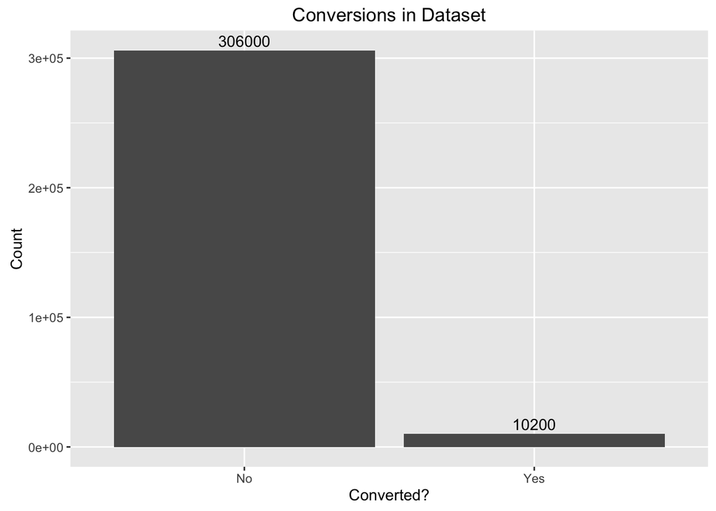

Visually inspecting the sources data:

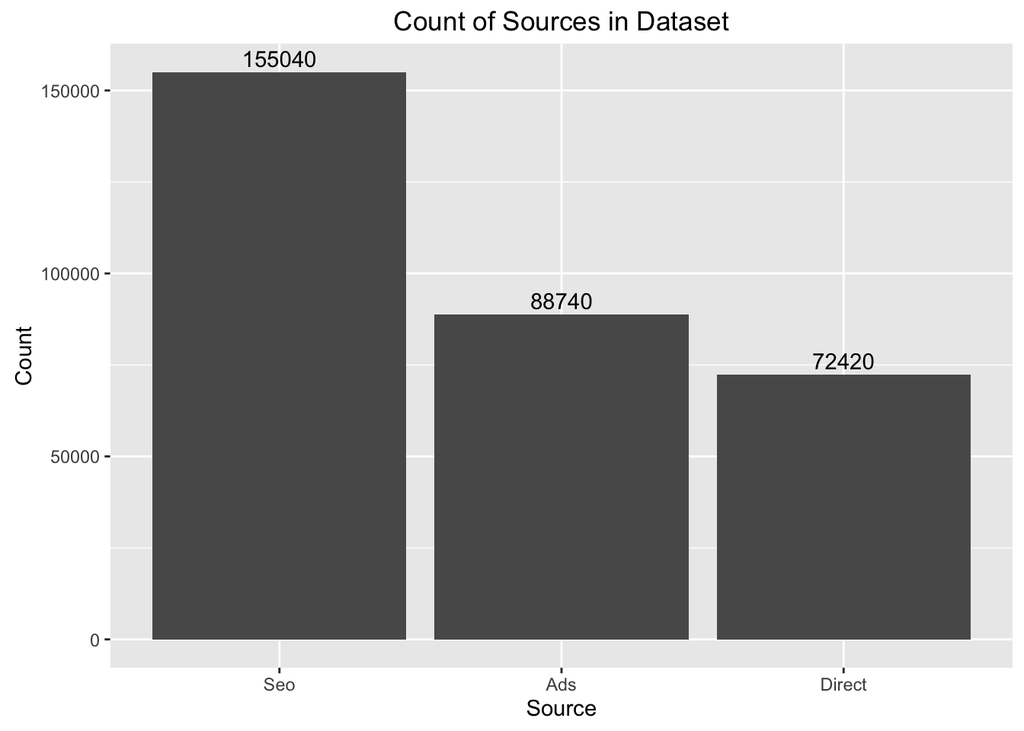

Visually inspecting the pages visited data:

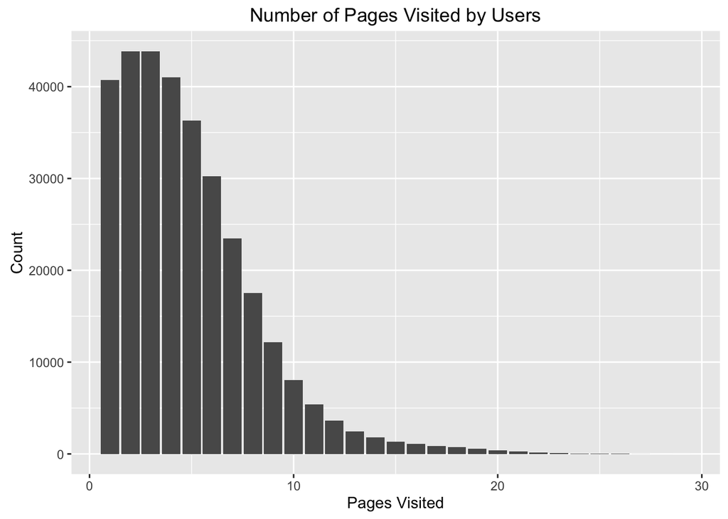

Let’s look at the age breakdown of the users on the site:

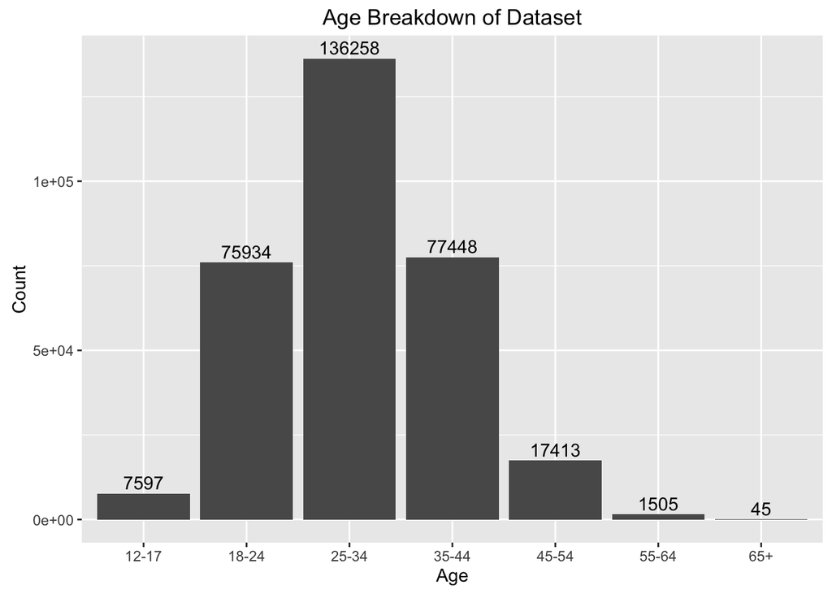

## Insights

- The current conversion rate in the dataset is **3.23%**
- We can see that a majority of the users are from the US.
- The age data has some data that needs to be validated as there is a user with age of 123 (very unlikely!)
- 49% of users are coming in via SEO; 28% of users via ads, and the remaining 23% are direct users.
- On average, a user will view 5 pages in a visit
- 68% of the users are creating new accounts

## Questions

Let’s look at a couple of questions:

1. Where are most of the conversions coming from? By source, by country?
2. What is the typical age of a converter?
3. What is the correlation between the factors in the dataset?

## Conversion Metrics

```r
data %>%
  filter(converted=="Yes") %>%
  group_by(source) %>%
  summarize(count=n())
```

```
## # A tibble: 3 × 2
##   source count
##   <fctr> <int>
## 1    Ads  3060
## 2 Direct  2040
## 3    Seo  5100
```

```r
data %>%
  filter(converted=="Yes") %>%
  group_by(country) %>%
  summarize(count=n())
```

```
## # A tibble: 4 × 2
##   country count
##    <fctr> <int>
## 1   China   102
## 2 Germany   816
## 3      UK  2550
## 4      US  6732
```

```r
data %>%
  filter(converted=="Yes") %>%
  group_by(bins) %>%
  summarize(count=n())
```

```
## # A tibble: 7 × 2
##     bins count
##   <fctr> <int>
## 1  12-17   544
## 2  18-24  4083
## 3  25-34  4182
## 4  35-44  1227
## 5  45-54   154
## 6  55-64     8
## 7    65+     2
```

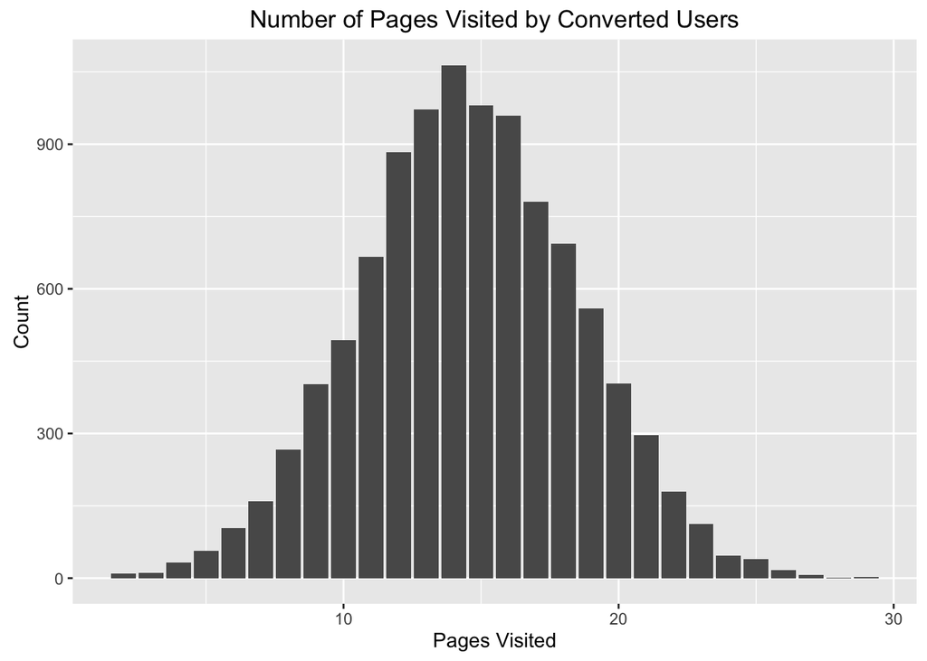

```r
data %>%
  filter(converted=="Yes") %>%
  group_by(total_pages_visited) %>%
  summarize(count=n()) %>%
  ggplot(aes(x=total_pages_visited, y=count)) +
  geom_bar(stat="identity") +
  xlab("Pages Visited") +
  ylab("Count") +
  ggtitle("Number of Pages Visited by Converted Users")
```